# Risk Factor Analysis

## Outcome Variable

**Outcome Variable:** wast_rec90d

## Predictor Variables

**Intervention Variable:** brthmon

**Adjustment Set:**

unadjusted

## Stratifying Variables

The analysis was stratified on these variable(s):

- agecat
- studyid
- country

## Data Summary

| agecat | studyid | country | brthmon | wast_rec90d | n_cell | n |
| --- | --- | --- | --- | --- | --- | --- |
| 0-24 months | CMC-V-BCS-2002 | INDIA | 1 | 0 | 9 | 324 |
| 0-24 months | CMC-V-BCS-2002 | INDIA | 1 | 1 | 19 | 324 |
| 0-24 months | CMC-V-BCS-2002 | INDIA | 2 | 0 | 3 | 324 |
| 0-24 months | CMC-V-BCS-2002 | INDIA | 2 | 1 | 6 | 324 |
| 0-24 months | CMC-V-BCS-2002 | INDIA | 3 | 0 | 10 | 324 |
| 0-24 months | CMC-V-BCS-2002 | INDIA | 3 | 1 | 13 | 324 |
| 0-24 months | CMC-V-BCS-2002 | INDIA | 4 | 0 | 17 | 324 |
| 0-24 months | CMC-V-BCS-2002 | INDIA | 4 | 1 | 18 | 324 |
| 0-24 months | CMC-V-BCS-2002 | INDIA | 5 | 0 | 9 | 324 |
| 0-24 months | CMC-V-BCS-2002 | INDIA | 5 | 1 | 17 | 324 |
| 0-24 months | CMC-V-BCS-2002 | INDIA | 6 | 0 | 11 | 324 |
| 0-24 months | CMC-V-BCS-2002 | INDIA | 6 | 1 | 25 | 324 |
| 0-24 months | CMC-V-BCS-2002 | INDIA | 7 | 0 | 16 | 324 |
| 0-24 months | CMC-V-BCS-2002 | INDIA | 7 | 1 | 9 | 324 |
| 0-24 months | CMC-V-BCS-2002 | INDIA | 8 | 0 | 7 | 324 |
| 0-24 months | CMC-V-BCS-2002 | INDIA | 8 | 1 | 14 | 324 |
| 0-24 months | CMC-V-BCS-2002 | INDIA | 9 | 0 | 6 | 324 |
| 0-24 months | CMC-V-BCS-2002 | INDIA | 9 | 1 | 14 | 324 |
| 0-24 months | CMC-V-BCS-2002 | INDIA | 10 | 0 | 8 | 324 |
| 0-24 months | CMC-V-BCS-2002 | INDIA | 10 | 1 | 23 | 324 |
| 0-24 months | CMC-V-BCS-2002 | INDIA | 11 | 0 | 14 | 324 |
| 0-24 months | CMC-V-BCS-2002 | INDIA | 11 | 1 | 29 | 324 |
| 0-24 months | CMC-V-BCS-2002 | INDIA | 12 | 0 | 10 | 324 |
| 0-24 months | CMC-V-BCS-2002 | INDIA | 12 | 1 | 17 | 324 |
| 0-24 months | CMIN | BANGLADESH | 1 | 0 | 6 | 190 |
| 0-24 months | CMIN | BANGLADESH | 1 | 1 | 12 | 190 |
| 0-24 months | CMIN | BANGLADESH | 2 | 0 | 5 | 190 |
| 0-24 months | CMIN | BANGLADESH | 2 | 1 | 12 | 190 |
| 0-24 months | CMIN | BANGLADESH | 3 | 0 | 4 | 190 |
| 0-24 months | CMIN | BANGLADESH | 3 | 1 | 12 | 190 |

[output cut: 1746 more lines]

The following strata were considered:

- agecat: 0-24 months, studyid: CMC-V-BCS-2002, country: INDIA
- agecat: 0-24 months, studyid: CMIN, country: BANGLADESH
- agecat: 0-24 months, studyid: CONTENT, country: PERU
- agecat: 0-24 months, studyid: EE, country: PAKISTAN
- agecat: 0-24 months, studyid: GMS-Nepal, country: NEPAL
- agecat: 0-24 months, studyid: Guatemala BSC, country: GUATEMALA
- agecat: 0-24 months, studyid: iLiNS-Zinc, country: BURKINA FASO
- agecat: 0-24 months, studyid: IRC, country: INDIA
- agecat: 0-24 months, studyid: Keneba, country: GAMBIA
- agecat: 0-24 months, studyid: LCNI-5, country: MALAWI
- agecat: 0-24 months, studyid: MAL-ED, country: BANGLADESH
- agecat: 0-24 months, studyid: MAL-ED, country: BRAZIL
- agecat: 0-24 months, studyid: MAL-ED, country: INDIA
- agecat: 0-24 months, studyid: MAL-ED, country: NEPAL
- agecat: 0-24 months, studyid: MAL-ED, country: PERU
- agecat: 0-24 months, studyid: MAL-ED, country: SOUTH AFRICA
- agecat: 0-24 months, studyid: MAL-ED, country: TANZANIA, UNITED REPUBLIC OF
- agecat: 0-24 months, studyid: NIH-Birth, country: BANGLADESH
- agecat: 0-24 months, studyid: PROBIT, country: BELARUS
- agecat: 0-24 months, studyid: PROVIDE, country: BANGLADESH
- agecat: 0-24 months, studyid: ResPak, country: PAKISTAN
- agecat: 0-24 months, studyid: SAS-CompFeed, country: INDIA
- agecat: 0-24 months, studyid: SAS-FoodSuppl, country: INDIA
- agecat: 0-24 months, studyid: TanzaniaChild2, country: TANZANIA, UNITED REPUBLIC OF
- agecat: 0-24 months, studyid: ZVITAMBO, country: ZIMBABWE
- agecat: 0-6 months, studyid: CMC-V-BCS-2002, country: INDIA
- agecat: 0-6 months, studyid: CMIN, country: BANGLADESH
- agecat: 0-6 months, studyid: CONTENT, country: PERU
- agecat: 0-6 months, studyid: EE, country: PAKISTAN
- agecat: 0-6 months, studyid: GMS-Nepal, country: NEPAL
- agecat: 0-6 months, studyid: Guatemala BSC, country: GUATEMALA
- agecat: 0-6 months, studyid: IRC, country: INDIA
- agecat: 0-6 months, studyid: Keneba, country: GAMBIA
- agecat: 0-6 months, studyid: LCNI-5, country: MALAWI
- agecat: 0-6 months, studyid: MAL-ED, country: BANGLADESH
- agecat: 0-6 months, studyid: MAL-ED, country: BRAZIL
- agecat: 0-6 months, studyid: MAL-ED, country: INDIA
- agecat: 0-6 months, studyid: MAL-ED, country: NEPAL
- agecat: 0-6 months, studyid: MAL-ED, country: PERU
- agecat: 0-6 months, studyid: MAL-ED, country: SOUTH AFRICA
- agecat: 0-6 months, studyid: MAL-ED, country: TANZANIA, UNITED REPUBLIC OF
- agecat: 0-6 months, studyid: NIH-Birth, country: BANGLADESH
- agecat: 0-6 months, studyid: PROBIT, country: BELARUS
- agecat: 0-6 months, studyid: PROVIDE, country: BANGLADESH
- agecat: 0-6 months, studyid: ResPak, country: PAKISTAN
- agecat: 0-6 months, studyid: SAS-CompFeed, country: INDIA
- agecat: 0-6 months, studyid: SAS-FoodSuppl, country: INDIA
- agecat: 0-6 months, studyid: TanzaniaChild2, country: TANZANIA, UNITED REPUBLIC OF
- agecat: 0-6 months, studyid: ZVITAMBO, country: ZIMBABWE
- agecat: 6-24 months, studyid: CMC-V-BCS-2002, country: INDIA
- agecat: 6-24 months, studyid: CMIN, country: BANGLADESH
- agecat: 6-24 months, studyid: CONTENT, country: PERU
- agecat: 6-24 months, studyid: EE, country: PAKISTAN
- agecat: 6-24 months, studyid: GMS-Nepal, country: NEPAL
- agecat: 6-24 months, studyid: Guatemala BSC, country: GUATEMALA
- agecat: 6-24 months, studyid: iLiNS-Zinc, country: BURKINA FASO
- agecat: 6-24 months, studyid: IRC, country: INDIA
- agecat: 6-24 months, studyid: Keneba, country: GAMBIA
- agecat: 6-24 months, studyid: LCNI-5, country: MALAWI
- agecat: 6-24 months, studyid: MAL-ED, country: BANGLADESH
- agecat: 6-24 months, studyid: MAL-ED, country: BRAZIL
- agecat: 6-24 months, studyid: MAL-ED, country: INDIA
- agecat: 6-24 months, studyid: MAL-ED, country: NEPAL
- agecat: 6-24 months, studyid: MAL-ED, country: PERU
- agecat: 6-24 months, studyid: MAL-ED, country: SOUTH AFRICA
- agecat: 6-24 months, studyid: MAL-ED, country: TANZANIA, UNITED REPUBLIC OF
- agecat: 6-24 months, studyid: NIH-Birth, country: BANGLADESH
- agecat: 6-24 months, studyid: PROBIT, country: BELARUS
- agecat: 6-24 months, studyid: PROVIDE, country: BANGLADESH
- agecat: 6-24 months, studyid: ResPak, country: PAKISTAN
- agecat: 6-24 months, studyid: SAS-CompFeed, country: INDIA
- agecat: 6-24 months, studyid: SAS-FoodSuppl, country: INDIA
- agecat: 6-24 months, studyid: TanzaniaChild2, country: TANZANIA, UNITED REPUBLIC OF
- agecat: 6-24 months, studyid: ZVITAMBO, country: ZIMBABWE

### Dropped Strata

Some strata were dropped due to rare outcomes:

- agecat: 0-24 months, studyid: CMC-V-BCS-2002, country: INDIA
- agecat: 0-24 months, studyid: CMIN, country: BANGLADESH
- agecat: 0-24 months, studyid: CONTENT, country: PERU
- agecat: 0-24 months, studyid: EE, country: PAKISTAN
- agecat: 0-24 months, studyid: GMS-Nepal, country: NEPAL
- agecat: 0-24 months, studyid: Guatemala BSC, country: GUATEMALA
- agecat: 0-24 months, studyid: iLiNS-Zinc, country: BURKINA FASO
- agecat: 0-24 months, studyid: LCNI-5, country: MALAWI
- agecat: 0-24 months, studyid: MAL-ED, country: BANGLADESH
- agecat: 0-24 months, studyid: MAL-ED, country: BRAZIL
- agecat: 0-24 months, studyid: MAL-ED, country: INDIA
- agecat: 0-24 months, studyid: MAL-ED, country: NEPAL
- agecat: 0-24 months, studyid: MAL-ED, country: PERU
- agecat: 0-24 months, studyid: MAL-ED, country: SOUTH AFRICA
- agecat: 0-24 months, studyid: MAL-ED, country: TANZANIA, UNITED REPUBLIC OF
- agecat: 0-24 months, studyid: PROVIDE, country: BANGLADESH
- agecat: 0-24 months, studyid: ResPak, country: PAKISTAN
- agecat: 0-24 months, studyid: SAS-FoodSuppl, country: INDIA
- agecat: 0-6 months, studyid: CMC-V-BCS-2002, country: INDIA
- agecat: 0-6 months, studyid: CMIN, country: BANGLADESH
- agecat: 0-6 months, studyid: CONTENT, country: PERU
- agecat: 0-6 months, studyid: EE, country: PAKISTAN
- agecat: 0-6 months, studyid: GMS-Nepal, country: NEPAL
- agecat: 0-6 months, studyid: Guatemala BSC, country: GUATEMALA
- agecat: 0-6 months, studyid: IRC, country: INDIA
- agecat: 0-6 months, studyid: LCNI-5, country: MALAWI
- agecat: 0-6 months, studyid: MAL-ED, country: BANGLADESH
- agecat: 0-6 months, studyid: MAL-ED, country: BRAZIL
- agecat: 0-6 months, studyid: MAL-ED, country: INDIA
- agecat: 0-6 months, studyid: MAL-ED, country: NEPAL
- agecat: 0-6 months, studyid: MAL-ED, country: PERU
- agecat: 0-6 months, studyid: MAL-ED, country: SOUTH AFRICA
- agecat: 0-6 months, studyid: MAL-ED, country: TANZANIA, UNITED REPUBLIC OF
- agecat: 0-6 months, studyid: NIH-Birth, country: BANGLADESH
- agecat: 0-6 months, studyid: PROVIDE, country: BANGLADESH
- agecat: 0-6 months, studyid: ResPak, country: PAKISTAN
- agecat: 0-6 months, studyid: SAS-FoodSuppl, country: INDIA
- agecat: 0-6 months, studyid: TanzaniaChild2, country: TANZANIA, UNITED REPUBLIC OF
- agecat: 6-24 months, studyid: CMC-V-BCS-2002, country: INDIA
- agecat: 6-24 months, studyid: CMIN, country: BANGLADESH
- agecat: 6-24 months, studyid: CONTENT, country: PERU
- agecat: 6-24 months, studyid: EE, country: PAKISTAN
- agecat: 6-24 months, studyid: GMS-Nepal, country: NEPAL
- agecat: 6-24 months, studyid: Guatemala BSC, country: GUATEMALA
- agecat: 6-24 months, studyid: iLiNS-Zinc, country: BURKINA FASO
- agecat: 6-24 months, studyid: IRC, country: INDIA
- agecat: 6-24 months, studyid: LCNI-5, country: MALAWI
- agecat: 6-24 months, studyid: MAL-ED, country: BANGLADESH
- agecat: 6-24 months, studyid: MAL-ED, country: BRAZIL
- agecat: 6-24 months, studyid: MAL-ED, country: INDIA
- agecat: 6-24 months, studyid: MAL-ED, country: NEPAL
- agecat: 6-24 months, studyid: MAL-ED, country: PERU
- agecat: 6-24 months, studyid: MAL-ED, country: SOUTH AFRICA
- agecat: 6-24 months, studyid: MAL-ED, country: TANZANIA, UNITED REPUBLIC OF
- agecat: 6-24 months, studyid: NIH-Birth, country: BANGLADESH
- agecat: 6-24 months, studyid: PROBIT, country: BELARUS
- agecat: 6-24 months, studyid: PROVIDE, country: BANGLADESH
- agecat: 6-24 months, studyid: ResPak, country: PAKISTAN
- agecat: 6-24 months, studyid: SAS-CompFeed, country: INDIA
- agecat: 6-24 months, studyid: SAS-FoodSuppl, country: INDIA
- agecat: 6-24 months, studyid: ZVITAMBO, country: ZIMBABWE

## Methods Detail

We’re interested in the causal parameters $E[Y_a]$ for all values of $a \in \mathcal{A}$. These parameters represent the mean outcome if, possibly contrary to fact, we intervened to set all units to have $A=a$. Under the randomization and positivity assumptions, these are identified by the statistical parameters $\psi_a=E_W[E_{Y|A,W}(Y|A=a,W)]$. In addition, we’re interested in the mean of $Y$, $E[Y]$ under no intervention (the observed mean). We will estimate these parameters by using SuperLearner to fit the relevant likelihood factors – $E_{Y|A,W}(Y|A=a,W)$ and $p(A=a|W)$, and then updating our likelihood fit using a joint TMLE.

For unadjusted analyses ($W=\{\}$), initial likelihoods were estimated using Lrnr_glm to estimate the simple $E(Y|A)$ and Lrnr_mean to estimate $p(A)$. For adjusted analyses, a small library containing Lrnr_glmnet, Lrnr_xgboost, and Lrnr_mean was used.

Having estimated these parameters, we will then use the delta method to estimate relative risks and attributable risks relative to a prespecified baseline level of $A$.

# Results Detail

## Results Plots

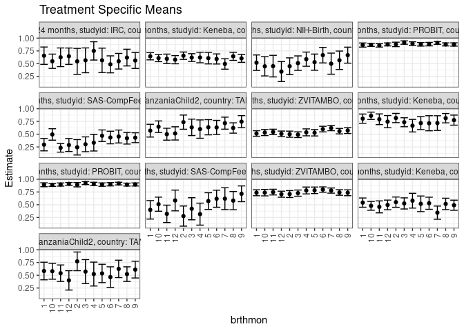

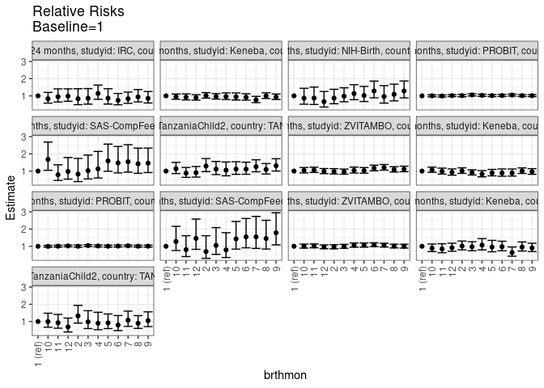

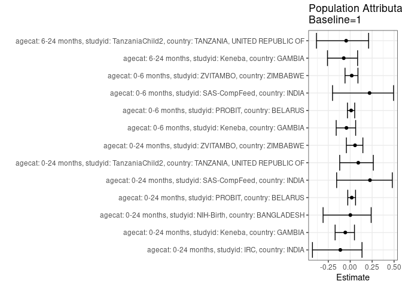

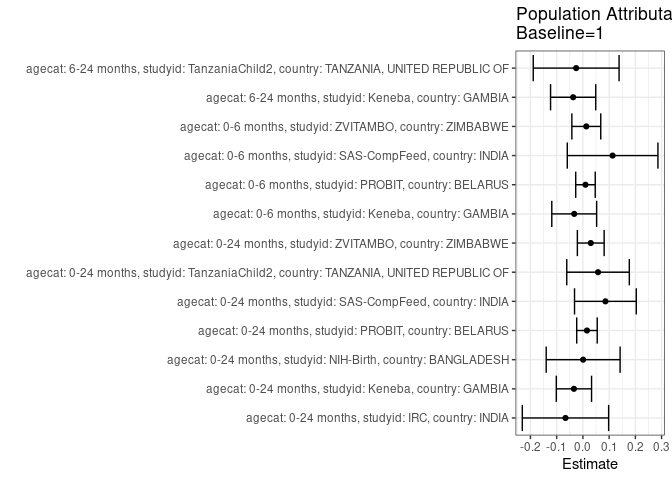

## Results Table

### Parameter: TSM

| agecat | studyid | country | intervention_level | baseline_level | estimate | ci_lower | ci_upper |
| --- | --- | --- | --- | --- | --- | --- | --- |
| 0-24 months | IRC | INDIA | 1 | NA | 0.6562500 | 0.4858806 | 0.8266194 |
| 0-24 months | IRC | INDIA | 2 | NA | 0.5454545 | 0.2915765 | 0.7993325 |
| 0-24 months | IRC | INDIA | 3 | NA | 0.5652174 | 0.3222657 | 0.8081691 |
| 0-24 months | IRC | INDIA | 4 | NA | 0.7500000 | 0.5708445 | 0.9291555 |
| 0-24 months | IRC | INDIA | 5 | NA | 0.5652174 | 0.3263159 | 0.8041189 |
| 0-24 months | IRC | INDIA | 6 | NA | 0.4864865 | 0.3200836 | 0.6528893 |
| 0-24 months | IRC | INDIA | 7 | NA | 0.5476190 | 0.3946365 | 0.7006016 |
| 0-24 months | IRC | INDIA | 8 | NA | 0.6190476 | 0.4554007 | 0.7826945 |
| 0-24 months | IRC | INDIA | 9 | NA | 0.5625000 | 0.4064115 | 0.7185885 |
| 0-24 months | IRC | INDIA | 10 | NA | 0.5476190 | 0.4075303 | 0.6877078 |
| 0-24 months | IRC | INDIA | 11 | NA | 0.6250000 | 0.4423429 | 0.8076571 |
| 0-24 months | IRC | INDIA | 12 | NA | 0.6458333 | 0.4853215 | 0.8063452 |
| 0-24 months | Keneba | GAMBIA | 1 | NA | 0.6446701 | 0.5739145 | 0.7154256 |
| 0-24 months | Keneba | GAMBIA | 2 | NA | 0.6555556 | 0.5832943 | 0.7278168 |
| 0-24 months | Keneba | GAMBIA | 3 | NA | 0.6193182 | 0.5433675 | 0.6952689 |
| 0-24 months | Keneba | GAMBIA | 4 | NA | 0.6203704 | 0.5170685 | 0.7236722 |
| 0-24 months | Keneba | GAMBIA | 5 | NA | 0.6078431 | 0.4944616 | 0.7212247 |
| 0-24 months | Keneba | GAMBIA | 6 | NA | 0.5922330 | 0.4931452 | 0.6913208 |
| 0-24 months | Keneba | GAMBIA | 7 | NA | 0.4948454 | 0.3921501 | 0.5975406 |
| 0-24 months | Keneba | GAMBIA | 8 | NA | 0.6441718 | 0.5650352 | 0.7233084 |
| 0-24 months | Keneba | GAMBIA | 9 | NA | 0.6035503 | 0.5261977 | 0.6809029 |
| 0-24 months | Keneba | GAMBIA | 10 | NA | 0.6084906 | 0.5387112 | 0.6782699 |
| 0-24 months | Keneba | GAMBIA | 11 | NA | 0.5957447 | 0.5041443 | 0.6873450 |
| 0-24 months | Keneba | GAMBIA | 12 | NA | 0.5777778 | 0.4975667 | 0.6579888 |
| 0-24 months | NIH-Birth | BANGLADESH | 1 | NA | 0.5192308 | 0.3677287 | 0.6707328 |
| 0-24 months | NIH-Birth | BANGLADESH | 2 | NA | 0.4500000 | 0.2860503 | 0.6139497 |
| 0-24 months | NIH-Birth | BANGLADESH | 3 | NA | 0.5102041 | 0.3682818 | 0.6521263 |
| 0-24 months | NIH-Birth | BANGLADESH | 4 | NA | 0.5882353 | 0.4490052 | 0.7274654 |
| 0-24 months | NIH-Birth | BANGLADESH | 5 | NA | 0.5294118 | 0.3709352 | 0.6878884 |
| 0-24 months | NIH-Birth | BANGLADESH | 6 | NA | 0.6666667 | 0.5144110 | 0.8189223 |

[output cut: 126 more lines]

### Parameter: E(Y)

| agecat | studyid | country | intervention_level | baseline_level | estimate | ci_lower | ci_upper |
| --- | --- | --- | --- | --- | --- | --- | --- |
| 0-24 months | IRC | INDIA | NA | NA | 0.5898734 | 0.5376978 | 0.6420491 |
| 0-24 months | Keneba | GAMBIA | NA | NA | 0.6105033 | 0.5863646 | 0.6346419 |
| 0-24 months | NIH-Birth | BANGLADESH | NA | NA | 0.5201900 | 0.4695846 | 0.5707955 |
| 0-24 months | PROBIT | BELARUS | NA | NA | 0.8806715 | 0.8711794 | 0.8901636 |
| 0-24 months | SAS-CompFeed | INDIA | NA | NA | 0.3808354 | 0.3457640 | 0.4159068 |
| 0-24 months | TanzaniaChild2 | TANZANIA, UNITED REPUBLIC OF | NA | NA | 0.6269285 | 0.5892870 | 0.6645700 |
| 0-24 months | ZVITAMBO | ZIMBABWE | NA | NA | 0.5432918 | 0.5268968 | 0.5596869 |
| 0-6 months | Keneba | GAMBIA | NA | NA | 0.7720994 | 0.7419223 | 0.8022766 |
| 0-6 months | PROBIT | BELARUS | NA | NA | 0.9008671 | 0.8918443 | 0.9098900 |
| 0-6 months | SAS-CompFeed | INDIA | NA | NA | 0.5131965 | 0.4596632 | 0.5667297 |
| 0-6 months | ZVITAMBO | ZIMBABWE | NA | NA | 0.7475189 | 0.7305656 | 0.7644721 |
| 6-24 months | Keneba | GAMBIA | NA | NA | 0.5045290 | 0.4730969 | 0.5359611 |
| 6-24 months | TanzaniaChild2 | TANZANIA, UNITED REPUBLIC OF | NA | NA | 0.5576408 | 0.5054408 | 0.6098407 |

### Parameter: RR

| agecat | studyid | country | intervention_level | baseline_level | estimate | ci_lower | ci_upper |
| --- | --- | --- | --- | --- | --- | --- | --- |
| 0-24 months | IRC | INDIA | 1 | 1 | 1.0000000 | 1.0000000 | 1.0000000 |
| 0-24 months | IRC | INDIA | 2 | 1 | 0.8311688 | 0.4877862 | 1.4162796 |
| 0-24 months | IRC | INDIA | 3 | 1 | 0.8612836 | 0.5212519 | 1.4231306 |
| 0-24 months | IRC | INDIA | 4 | 1 | 1.1428571 | 0.8031822 | 1.6261844 |
| 0-24 months | IRC | INDIA | 5 | 1 | 0.8612836 | 0.5244892 | 1.4143465 |
| 0-24 months | IRC | INDIA | 6 | 1 | 0.7413127 | 0.4825216 | 1.1389015 |
| 0-24 months | IRC | INDIA | 7 | 1 | 0.8344671 | 0.5698740 | 1.2219111 |
| 0-24 months | IRC | INDIA | 8 | 1 | 0.9433107 | 0.6512338 | 1.3663833 |
| 0-24 months | IRC | INDIA | 9 | 1 | 0.8571429 | 0.5861637 | 1.2533938 |
| 0-24 months | IRC | INDIA | 10 | 1 | 0.8344671 | 0.5796238 | 1.2013575 |
| 0-24 months | IRC | INDIA | 11 | 1 | 0.9523810 | 0.6442355 | 1.4079161 |
| 0-24 months | IRC | INDIA | 12 | 1 | 0.9841270 | 0.6870088 | 1.4097430 |
| 0-24 months | Keneba | GAMBIA | 1 | 1 | 1.0000000 | 1.0000000 | 1.0000000 |
| 0-24 months | Keneba | GAMBIA | 2 | 1 | 1.0168854 | 0.8703959 | 1.1880293 |
| 0-24 months | Keneba | GAMBIA | 3 | 1 | 0.9606747 | 0.8148937 | 1.1325352 |
| 0-24 months | Keneba | GAMBIA | 4 | 1 | 0.9623068 | 0.7883182 | 1.1746962 |
| 0-24 months | Keneba | GAMBIA | 5 | 1 | 0.9428748 | 0.7593835 | 1.1707034 |
| 0-24 months | Keneba | GAMBIA | 6 | 1 | 0.9186607 | 0.7520641 | 1.1221615 |
| 0-24 months | Keneba | GAMBIA | 7 | 1 | 0.7675948 | 0.6069800 | 0.9707103 |
| 0-24 months | Keneba | GAMBIA | 8 | 1 | 0.9992271 | 0.8474610 | 1.1781719 |
| 0-24 months | Keneba | GAMBIA | 9 | 1 | 0.9362158 | 0.7908497 | 1.1083016 |
| 0-24 months | Keneba | GAMBIA | 10 | 1 | 0.9438791 | 0.8053380 | 1.1062531 |
| 0-24 months | Keneba | GAMBIA | 11 | 1 | 0.9241079 | 0.7650320 | 1.1162610 |
| 0-24 months | Keneba | GAMBIA | 12 | 1 | 0.8962380 | 0.7508719 | 1.0697464 |
| 0-24 months | NIH-Birth | BANGLADESH | 1 | 1 | 1.0000000 | 1.0000000 | 1.0000000 |
| 0-24 months | NIH-Birth | BANGLADESH | 2 | 1 | 0.8666667 | 0.5434712 | 1.3820625 |
| 0-24 months | NIH-Birth | BANGLADESH | 3 | 1 | 0.9826153 | 0.6566845 | 1.4703145 |
| 0-24 months | NIH-Birth | BANGLADESH | 4 | 1 | 1.1328976 | 0.7781631 | 1.6493418 |
| 0-24 months | NIH-Birth | BANGLADESH | 5 | 1 | 1.0196078 | 0.6713033 | 1.5486295 |
| 0-24 months | NIH-Birth | BANGLADESH | 6 | 1 | 1.2839506 | 0.8865229 | 1.8595450 |

[output cut: 126 more lines]

### Parameter: PAR

| agecat | studyid | country | intervention_level | baseline_level | estimate | ci_lower | ci_upper |
| --- | --- | --- | --- | --- | --- | --- | --- |
| 0-24 months | IRC | INDIA | 1 | NA | -0.0663766 | -0.2308937 | 0.0981406 |
| 0-24 months | Keneba | GAMBIA | 1 | NA | -0.0341668 | -0.1013205 | 0.0329869 |
| 0-24 months | NIH-Birth | BANGLADESH | 1 | NA | 0.0009593 | -0.1398662 | 0.1417847 |
| 0-24 months | PROBIT | BELARUS | 1 | NA | 0.0155030 | -0.0235840 | 0.0545899 |
| 0-24 months | SAS-CompFeed | INDIA | 1 | NA | 0.0857534 | -0.0319095 | 0.2034163 |
| 0-24 months | TanzaniaChild2 | TANZANIA, UNITED REPUBLIC OF | 1 | NA | 0.0576977 | -0.0615111 | 0.1769065 |
| 0-24 months | ZVITAMBO | ZIMBABWE | 1 | NA | 0.0299387 | -0.0210775 | 0.0809550 |
| 0-6 months | Keneba | GAMBIA | 1 | NA | -0.0330954 | -0.1185739 | 0.0523832 |
| 0-6 months | PROBIT | BELARUS | 1 | NA | 0.0098165 | -0.0273788 | 0.0470118 |
| 0-6 months | SAS-CompFeed | INDIA | 1 | NA | 0.1131965 | -0.0595023 | 0.2858953 |
| 0-6 months | ZVITAMBO | ZIMBABWE | 1 | NA | 0.0130056 | -0.0420404 | 0.0680516 |
| 6-24 months | Keneba | GAMBIA | 1 | NA | -0.0371377 | -0.1232285 | 0.0489531 |
| 6-24 months | TanzaniaChild2 | TANZANIA, UNITED REPUBLIC OF | 1 | NA | -0.0256926 | -0.1892618 | 0.1378766 |

### Parameter: PAF

| agecat | studyid | country | intervention_level | baseline_level | estimate | ci_lower | ci_upper |
| --- | --- | --- | --- | --- | --- | --- | --- |
| 0-24 months | IRC | INDIA | 1 | NA | -0.1125268 | -0.4302983 | 0.1346449 |
| 0-24 months | Keneba | GAMBIA | 1 | NA | -0.0559649 | -0.1719853 | 0.0485700 |
| 0-24 months | NIH-Birth | BANGLADESH | 1 | NA | 0.0018440 | -0.3091534 | 0.2389621 |
| 0-24 months | PROBIT | BELARUS | 1 | NA | 0.0176036 | -0.0278026 | 0.0610038 |
| 0-24 months | SAS-CompFeed | INDIA | 1 | NA | 0.2251719 | -0.1544827 | 0.4799761 |
| 0-24 months | TanzaniaChild2 | TANZANIA, UNITED REPUBLIC OF | 1 | NA | 0.0920324 | -0.1196086 | 0.2636665 |
| 0-24 months | ZVITAMBO | ZIMBABWE | 1 | NA | 0.0551062 | -0.0436323 | 0.1445029 |
| 0-6 months | Keneba | GAMBIA | 1 | NA | -0.0428641 | -0.1597103 | 0.0622093 |
| 0-6 months | PROBIT | BELARUS | 1 | NA | 0.0108968 | -0.0312682 | 0.0513378 |
| 0-6 months | SAS-CompFeed | INDIA | 1 | NA | 0.2205714 | -0.2015354 | 0.4943895 |
| 0-6 months | ZVITAMBO | ZIMBABWE | 1 | NA | 0.0173983 | -0.0590764 | 0.0883509 |
| 6-24 months | Keneba | GAMBIA | 1 | NA | -0.0736086 | -0.2588170 | 0.0843502 |
| 6-24 months | TanzaniaChild2 | TANZANIA, UNITED REPUBLIC OF | 1 | NA | -0.0460737 | -0.3845951 | 0.2096821 |